# Trabajo Práctico 1: Regresión Lineal

Mauro Lucini

## Importación de Librerías

Se realiza la importación de librerías que se utilizaran en el desarrollo del trabajo.

```r
#Librerias para modificar dataframes y modelizar
library(tidyverse)
library(reshape2)
library(tidymodels)
library(robustbase)


#Librerias para graficar
library(ggplot2)
library(ggthemes)
library(ggrepel)
library(scales)
library(ggpubr)
```

## Carga de Dataset utilizar

Se importa los tres archivos ofrecidos para el análisis

```r
# Importo el dataset de train
encuesta_train <- read_csv("/home/mauro/Escritorio/Facultad/Data Mining/Enfoque Estadístico del Aprendizaje/Trabajo Práctico/data/encuesta_salud_train.csv",show_col_types = FALSE)
# Importo el dataset de test
encuesta_test <- read_csv("/home/mauro/Escritorio/Facultad/Data Mining/Enfoque Estadístico del Aprendizaje/Trabajo Práctico/data/encuesta_salud_test.csv",show_col_types = FALSE)
# Importo el dataset del modelo 6
encuesta_modelo6 <- read_csv("/home/mauro/Escritorio/Facultad/Data Mining/Enfoque Estadístico del Aprendizaje/Trabajo Práctico/data/encuesta_salud_modelo6.csv",show_col_types = FALSE)
```

## 1) Análisis Exploratorio

Como primer paso se utiliza la función Glimpse para poder realizar un rápido vistazo de los datos con los que contamos y su tipo:

```r
# Visualizo un resumen de las variables y sus types
glimpse(encuesta_train)
```

```
## Rows: 7,024
## Columns: 16
## $ record                        <dbl> 502, 26488, 31473, 14154, 36578, 53730, …
## $ edad                          <dbl> 17, 15, 15, 16, 17, 15, 13, 17, 17, 16, …
## $ genero                        <chr> "Femenino", "Masculino", "Masculino", "M…
## $ nivel_educativo               <chr> "2do año/11vo grado nivel Polimodal o 4t…
## $ altura                        <dbl> 165, 178, 172, 170, 170, 178, 156, 163, …
## $ peso                          <dbl> 62, 62, 62, 65, 75, 88, 46, 60, 57, 51, …
## $ frecuencia_hambre_mensual     <chr> "Rara vez", "Rara vez", "Nunca", "Nunca"…
## $ dias_consumo_comida_rapida    <dbl> 0, 0, 3, 1, 1, 2, 0, 0, 0, 3, 4, 2, 1, 1…
## $ edad_consumo_alcohol          <chr> "14 o 15 años", "7 años o menos", "Nunca…
## $ consumo_diario_alcohol        <dbl> 5.0, 4.0, 0.0, 0.0, 0.0, 5.0, 1.0, 0.5, …
## $ dias_actividad_fisica_semanal <dbl> 7, 7, 7, 7, 0, 7, 0, 2, 7, 3, 2, 2, 7, 1…
## $ consumo_semanal_frutas        <chr> "No comí frutas durante los últimos 7 dí…
## $ consumo_semanal_verdura       <chr> "4 a 6 veces durante los últimos 7 días"…
## $ consumo_semanal_gaseosas      <chr> "1 a 3 veces durante los últimos 7 días"…
## $ consumo_semanal_snacks        <chr> "1 a 3 veces durante los últimos 7 días"…
## $ consumo_semanal_comida_grasa  <chr> "No comí comida alta en grasa en los últ…
```

Se puede ver que tenemos las siguiente variables numéricas: record(es un id), edad, altura, peso, dias_consumo_comida_rapida, consumo_diario_alcohol y dias_actividad_fisica_semanal.

Las demás son variables del tipo cualitativas.

Se verifica los valores únicos de esta para las variables categóricas para conocer su cantidad y también un chequeo de NaNs.

```r
#Creamos una tabla para explorar variables
tabla_exploratorios =  encuesta_train %>%
                                      gather(.,
                                            key = "variables",
                                            value = "valores") %>%
                                      group_by(variables) %>%  #agrupamos por las variables
                                      summarise(valores_unicos = n_distinct(valores), #revisamos los valores unicos
                                      porcentaje_faltantes = sum(is.na(valores))/nrow(encuesta_train)*100) %>% #vemos el porcentaje de Nans
                                      arrange(desc(porcentaje_faltantes), valores_unicos) # ordenamos por porcentaje de faltantes y valores unicos
tabla_exploratorios
```

| variables | valores_unicos | porcentaje_faltantes |
| --- | --- | --- |
| genero | 2 | 0 |
| frecuencia_hambre_mensual | 6 | 0 |
| nivel_educativo | 6 | 0 |
| consumo_diario_alcohol | 7 | 0 |
| edad | 7 | 0 |
| consumo_semanal_comida_grasa | 8 | 0 |
| consumo_semanal_frutas | 8 | 0 |
| consumo_semanal_gaseosas | 8 | 0 |
| consumo_semanal_snacks | 8 | 0 |
| consumo_semanal_verdura | 8 | 0 |

[output cut: 6 more lines]

Notamos que pese a ser variables cualitativas sus valores únicos son relativamente pocos por lo que no tendremos matrices tan ralas en el análisis posterior. También denota que no hay nulos.

### Gráfico de Matriz de Correlaciones

Se realiza un gráfico para medir la correlación entre las distintas variables numéricas. En la siguiente matriz no incluiremos el género.

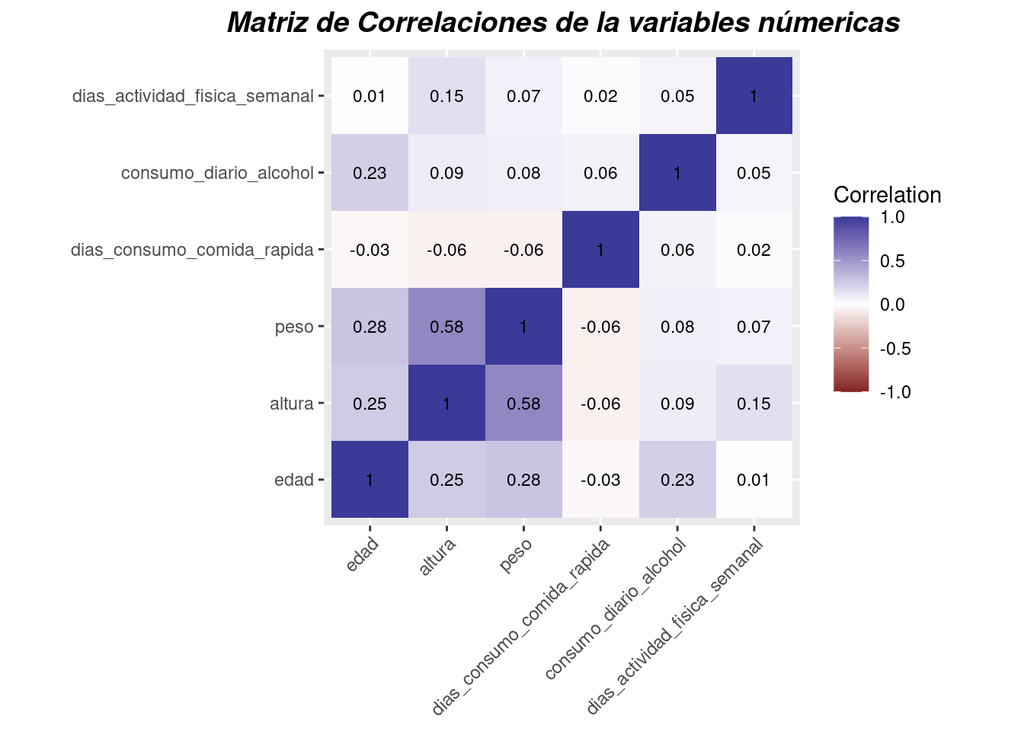

```r
# Se crea la matriz de correlación
matriz_corr <- round(cor(encuesta_train%>%
  select(edad, altura, peso, dias_consumo_comida_rapida,consumo_diario_alcohol,dias_actividad_fisica_semanal)),2)

# Se usa melt para poder introducirla en ggplot
matriz_corr <- melt(matriz_corr)

# Se crea heatmap con las correlaciones
ggplot(data = matriz_corr, aes(x=Var1, y=Var2, fill=value)) +
  geom_tile()+
  geom_text(aes(Var2, Var1, label = value), color = "black", size = 3) + # añado el los valores
 scale_fill_gradient2(midpoint = 0, limit = c(-1,1), space = "Lab", # cambio el gradiente de leyenda y el texto
   name="Correlation") +
 theme(axis.text.x = element_text(angle = 45, vjust = 1,# Ajusto el text a 45 grados de la x
    size = 9, hjust = 1),
    plot.title = element_text(color="black", size=14, face="bold.italic",hjust = 0.5), # ajusto el titulo
  axis.title.x = element_blank(), # borro el titulo de eje x
  axis.title.y = element_blank())+ # borro el titulo de eje y
  ggtitle("Matriz de Correlaciones de la variables númericas")+ # genero el texto del titulo
 coord_fixed()
```

De la siguiente matriz observamos una correlación máxima de 0.58 entre peso y altura lo cual era esperable. Luego se encuentra también otra correlación entre Edad y Peso con 0.28 que también hace mucho sentido ya que son las etapas de los niños donde muchos realizan un gran crecimiento altura (si chequeamos la correlación entre altura y edad vemos que tiene un valor similar de 0.25). El resto ya son muy cercanos a cero por lo que en principio parecería que no aportan mucha información al análisis de correlaciones.

### Revisión de variables en función del Género.

Se realiza una revisión de la variable Peso y Altura en función del Género. Se análizan las siguientes variable debido a que la primera es la variable a predecir y la segunda porque puede entenderse que existe una diferencia en el peso asociada a la altura que luego se tratará de verificar. Se utilizan boxplots para esto:

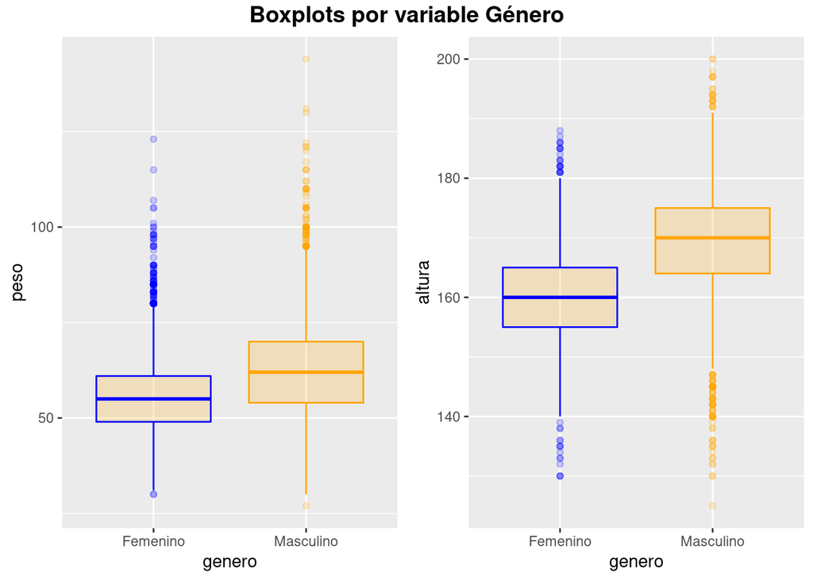

```r
# Guardo el boxplot de peso en función del genero
box_peso <- ggplot(encuesta_train, aes(x = genero, y = peso))+
  geom_boxplot(color=c("blue","orange"), fill="orange", alpha=0.2) # Defino colores y filling

# Guardo el boxplot de altura en función del genero
box_altura <- ggplot(encuesta_train, aes(x = genero, y = altura))+
  geom_boxplot(color=c("blue","orange"), fill="orange", alpha=0.2) # Defino colores y filling

# Genero Plot concatenando los dos boxplots
plot <- ggarrange(box_peso, box_altura,
                    ncol = 2, nrow = 1, common.legend = TRUE)
# Utilizo esta función para poner un título.
annotate_figure(plot, top = text_grob("Boxplots por variable Género",
               color = "black", face = "bold", size = 14))
```

Como se supuso, en general, los que poseen género masculino tiene un peso en promedio por encima al género femenino así como su altura. A su vez vemos también que alcanzar valores maximos mayores.

### Agregamos el género a las correlaciones

Para esto se crea una nueva variable numérica que indica 1 cuando se trata de Femenino y 0 cuando se trata de Masculino.

```r
# Cambio la variable genero a númerica

encuesta_train <- encuesta_train%>%
  mutate(genero_n=case_when(
    .$genero=="Femenino" ~ 1,
    .$genero=="Masculino" ~ 0
    ))

# También en el test
encuesta_test <- encuesta_test%>%
  mutate(genero_n=case_when(
    .$genero=="Femenino" ~ 1,
    .$genero=="Masculino" ~ 0
    ))
```

Realizamos el gráfico de la Matriz de Correlaciones con esta adición.

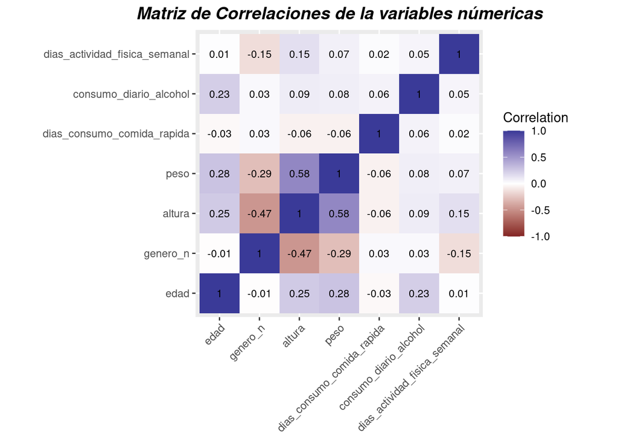

```r
# Se crea la matriz de correlación
matriz_corr <- round(cor(encuesta_train%>%
  select(edad, genero_n, altura, peso, dias_consumo_comida_rapida,consumo_diario_alcohol,dias_actividad_fisica_semanal)),2)

# Se usa melt para poder introducirla en ggplot
matriz_corr <- melt(matriz_corr)

# Se crea heatmap con las correlaciones
ggplot(data = matriz_corr, aes(x=Var1, y=Var2, fill=value)) +
  geom_tile()+
  geom_text(aes(Var2, Var1, label = value), color = "black", size = 3) + # añado el los valores
 scale_fill_gradient2(midpoint = 0, limit = c(-1,1), space = "Lab", # cambio el gradiente de leyenda y el texto
   name="Correlation") +
 theme(axis.text.x = element_text(angle = 45, vjust = 1,# Ajusto el text a 45 grados de la x
    size = 9, hjust = 1),
    plot.title = element_text(color="black", size=14, face="bold.italic",hjust = 0.5), # ajusto el titulo
  axis.title.x = element_blank(), # borro el titulo de eje x
  axis.title.y = element_blank())+ # borro el titulo de eje y
  ggtitle("Matriz de Correlaciones de la variables númericas")+ # genero el texto del titulo
 coord_fixed()
```

### Análisis de la frecuencia de Hambre en relación al consumo de frutas y al consumo de alimentos grasos

Calculamos con un group_by las frecuencias absolutas de las apariciones entre consumo de frutas semanal y frecuencia de hambre mensual. Realizamos el mismo agrupamiento pero con el consumo de comida grasa semanal.

Por último realizamos el gráfico de histogramas para poder visualizar con mayor facilidad estos datos.

```r
freq_hambre_fruta <- encuesta_train %>%
  group_by(frecuencia_hambre_mensual, consumo_semanal_frutas) %>% #agrupamos por las variables
  summarise(freq_absoluta = n()) %>% #hacemos un count
  mutate(freq_relativa = freq_absoluta / sum(freq_absoluta)) #Sacamos la frencuencia absoluta con sum
freq_hambre_fruta
```

| frecuencia_hambre_mensual | consumo_semanal_frutas | freq_absoluta | freq_relativa |
| --- | --- | --- | --- |
| Algunas veces | 1 a 3 veces durante los últimos 7 días | 202 | 0.342954160 |
| Algunas veces | 1 vez al día | 77 | 0.130730051 |
| Algunas veces | 2 veces al día | 56 | 0.095076401 |
| Algunas veces | 3 veces al día | 17 | 0.028862479 |
| Algunas veces | 4 a 6 veces durante los últimos 7 días | 58 | 0.098471986 |
| Algunas veces | 4 o más veces al día | 16 | 0.027164686 |
| Algunas veces | No comí frutas durante los últimos 7 días | 163 | 0.276740238 |
| Casi siempre | 1 a 3 veces durante los últimos 7 días | 19 | 0.243589744 |
| Casi siempre | 1 vez al día | 6 | 0.076923077 |
| Casi siempre | 2 veces al día | 4 | 0.051282051 |

[output cut: 35 more lines]

```r
freq_hambre_comidagrasa<- encuesta_train %>%
  group_by(frecuencia_hambre_mensual, consumo_semanal_comida_grasa) %>% #agrupamos por las variables
  summarise(freq_absoluta = n()) %>% #hacemos un count
  mutate(freq_relativa = freq_absoluta / sum(freq_absoluta)) #Sacamos la frencuencia absoluta con sum
freq_hambre_comidagrasa
```

| frecuencia_hambre_mensual | consumo_semanal_comida_grasa | freq_absoluta | freq_relativa |
| --- | --- | --- | --- |
| Algunas veces | 1 a 3 veces durante los últimos 7 días | 252 | 0.427843803 |
| Algunas veces | 1 vez al día | 62 | 0.105263158 |
| Algunas veces | 2 veces al día | 33 | 0.056027165 |
| Algunas veces | 3 veces al día | 18 | 0.030560272 |
| Algunas veces | 4 a 6 veces durante los últimos 7 días | 81 | 0.137521222 |
| Algunas veces | 4 o más veces al día | 24 | 0.040747029 |
| Algunas veces | Dato perdido | 4 | 0.006791171 |
| Algunas veces | No comí comida alta en grasa en los últimos 7 días | 115 | 0.195246180 |
| Casi siempre | 1 a 3 veces durante los últimos 7 días | 27 | 0.346153846 |
| Casi siempre | 1 vez al día | 6 | 0.076923077 |

[output cut: 33 more lines]

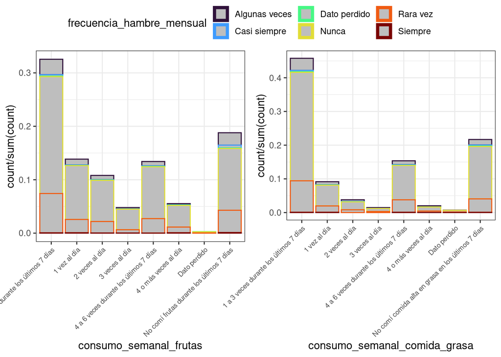

```r
hist_comida_grasa <- ggplot(encuesta_train, aes(x=consumo_semanal_comida_grasa,color=frecuencia_hambre_mensual))+
  geom_histogram(aes(y = stat(count) / sum(count)), stat="count",fill="grey") +
    theme_bw()+
 theme(axis.text.x = element_text(angle = 45, vjust = 1,# Ajusto el text a 45 grados de la x
    size = 7, hjust = 1)) +
     scale_color_viridis_d(option = "turbo",
                           guide = guide_legend(override.aes = list(size = 3) ) )



hist_fruta <- ggplot(encuesta_train, aes(x=consumo_semanal_frutas,color=frecuencia_hambre_mensual))+
  geom_histogram(aes(y = stat(count) / sum(count)), stat="count",fill="grey") +
    theme_bw()+
 theme(axis.text.x = element_text(angle = 45, vjust = 1,# Ajusto el text a 45 grados de la x
    size = 7, hjust = 1)) +
     scale_color_viridis_d(option = "turbo",
                           guide = guide_legend(override.aes = list(size = 3) ) )


ggarrange(hist_fruta, hist_comida_grasa,
                    ncol = 2, nrow = 1, common.legend = TRUE)
```

En ambos gráficos, se nota como primer medida que hay muy pocas apariciones de “Siempre” y “Casi Siempre” en frecuencia de hambre mensual. Esto da un indicio de que no hay demasiados alumnos de secundaria que pasen hambre dentro de la encuesta.

Luego se identifica que la mayoría de la observaciones se encuentran en los que comen entre 1 y 3 veces a la semana por lo menos 1 de esto grupos de alimentos o que directamente no los consumen. Además parecería que hay una mayor tendencia de hambruna en estos casos (más presencia de “algunas veces” y “Rara vez”) que podría ser explicado ya que los alimentos grasos ser altos en calorías lo cual reduce el apetito y lo mismo pasa con la fruta pero debido a que estos suelen contener azucares y suelen ocupar volumen en el estomago que también genera sensación de saciedad.

## 2) Modelo inicial

Se realiza el primer modelo lineal como lo indica la consigna:

$E(peso) = \beta_0 +\beta_1 altura+\beta_2 edad+\beta_3 genero+\beta_4 diasActividadFisicaSemanal +\beta_5 consumoDiarioAlcohol$

```r
# Selecciono las variables a utilizar

df_modelo_inicial <-  encuesta_train %>%
  select(peso, altura, edad,genero,dias_actividad_fisica_semanal,consumo_diario_alcohol)

# utilizo lm para entrenar el modelo inicial con las variables anteriores
modelo_inicial <- lm(peso ~ altura + edad + genero + dias_actividad_fisica_semanal + consumo_diario_alcohol, data = df_modelo_inicial)
```

Se utiliza la función tidy que devuelve las principales métricas de análasis.

```r
# Ejecuto tidy para ver las salidas del modelo
tidy_meg <- tidy(modelo_inicial, conf.int = TRUE)
tidy_meg
```

| term | estimate | std.error | statistic | p.value | conf.low | conf.high |
| --- | --- | --- | --- | --- | --- | --- |
| (Intercept) | -68.922688070 | 2.33805445 | -29.4786497 | 3.614866e-180 | -73.5059810 | -64.33939510 |
| altura | 0.650606544 | 0.01437975 | 45.2446353 | 0.000000e+00 | 0.6224179 | 0.67879520 |
| edad | 1.406727060 | 0.09385081 | 14.9889709 | 5.121599e-50 | 1.2227511 | 1.59070300 |
| generoMasculino | 1.262643558 | 0.27282821 | 4.6279802 | 3.758831e-06 | 0.7278179 | 1.79746926 |
| dias_actividad_fisica_semanal | -0.087391031 | 0.04992917 | -1.7503000 | 8.011025e-02 | -0.1852673 | 0.01048523 |
| consumo_diario_alcohol | 0.007271379 | 0.06138558 | 0.1184542 | 9.057112e-01 | -0.1130629 | 0.12760566 |

Para verificar de mejor forma la significatividad individual seleccionaremos la métrica del estadístico t, el p-valor, y los valores del intervalos de confianza. También se aplica un redondeo para visualizar mejor el pvalor.

```r
# Ejecuto tidy para ver las salidas del modelo filtrando por las de interes y redondeando el p valor
tidy_meg %>%
  select(term, statistic, p.value, conf.low, conf.high)%>%
  mutate(p.value = round(p.value, 4))
```

| term | statistic | p.value | conf.low | conf.high |
| --- | --- | --- | --- | --- |
| (Intercept) | -29.4786497 | 0.0000 | -73.5059810 | -64.33939510 |
| altura | 45.2446353 | 0.0000 | 0.6224179 | 0.67879520 |
| edad | 14.9889709 | 0.0000 | 1.2227511 | 1.59070300 |
| generoMasculino | 4.6279802 | 0.0000 | 0.7278179 | 1.79746926 |
| dias_actividad_fisica_semanal | -1.7503000 | 0.0801 | -0.1852673 | 0.01048523 |
| consumo_diario_alcohol | 0.1184542 | 0.9057 | -0.1130629 | 0.12760566 |

Debido a que el p-valor es menor 0.05, podemos afirmar que la altura, la edad y el género son variables significativas en el modelo. Podemos ver además que el estadístico es muy alto y los intervalos de confianza no contiene al cero. Cabe destacar que la variable género se encuentra como una categoría basal generoMasculino resultando siginificativo como se indica anteriormente.

Se rechaza la significatividad del consumo diario de alcohol y la cantidad de días de actividad física porque poseen p-valor mayores a 0.05. En estos casos además los intervalos de confianza contienen al cero.

Para evaluar si el modelo resulta explicativo se utilizará broom:glance para ver el coeficiente de determinación $R^2$ y $R^2$ ajustado

```r
# Ejecuto glance de la Liberia broom para ver el R2 y R2 ajustado del modelo

broom::glance(modelo_inicial)
```

| r.squared | adj.r.squared | sigma | statistic | p.value | df | logLik | AIC | BIC | deviance | df.residual | nobs |
| --- | --- | --- | --- | --- | --- | --- | --- | --- | --- | --- | --- |
| 0.3543754 | 0.3539154 | 9.914373 | 770.4188 | 0 | 5 | -26076.58 | 52167.16 | 52215.15 | 689832.9 | 7018 | 7024 |

Se identifica un $R^2$ de 0.3544 y un $R^2$ ajustado 0.3539. Esto nos permite decir que el modelo explica un 0.35 de la variabilidad y a su vez como el ajustado esta muy próximo al real, es una buena medida de que el modelo no esta sufriendo el agrado de muchas variables adicionales.

Se evalua la significatividad global del modelo, haciendo foco en el Test F, donde podremos ver que este estadistico es un número elevado generando un p valor de 2.2e-16 (menos a 0.05), por lo que hay evidencia suficiente para rechazar que no haya vinculo entre las variables respuesta y las regresoras.

## 3) Modelo con Variables Categóricas

Se evaluará un modelos con la inclusión de variables categóricas y una interacción entre género y edad, como el siguiente:

$E(peso) = \beta_0 +\beta_1 altura+\beta_2 edad+\beta_3 genero+\beta_4 consumoSemanalSnacks +\beta_5 genero*edad$

También se deberá usar relevel para cambiar la categoría basal de consumo_semanal_snacks para que esta sea “No comí comida salada o snacks en los últimos 7 días”. Esta interpretación es buena para efectivamente poder evaluar si su consumo aumenta o disminuye su estadistico en la predicción del Peso.

```r
#filtro el dataframe por las variables a utilizar en el modelo categóricas
df_modelo_categoricas <-  encuesta_train %>%
  select(peso, altura, edad,genero,consumo_semanal_snacks)
#Factorizo con factor() la variable de consumo de snack
df_modelo_categoricas$consumo_semanal_snacksFactor <- factor(df_modelo_categoricas$consumo_semanal_snacks)

#Uso relevel para cambiar la categoría basal
df_modelo_categoricas$consumo_semanal_snacksFactor <- relevel(df_modelo_categoricas$consumo_semanal_snacksFactor, ref = "No comí comida salada o snacks en los últimos 7 días")
# Entreno el modelo de variables categóricas
modelo_categoricas <- lm(peso ~ altura + edad + genero +  consumo_semanal_snacksFactor + edad * genero, data = df_modelo_categoricas)
```

Volvemos a utilizar tanto la función tidy como broom:glance para hacer las evualiciones pertinentes.

```r
modelo_categoricas <- lm(peso ~ altura + edad + genero +  consumo_semanal_snacksFactor + edad * genero, data = df_modelo_categoricas)
# Ejecuto tidy para ver las salidas del modelo seleccionando las variables que nos son de interes y redondeando el p-valor
tidy_meg <- tidy(modelo_categoricas, conf.int = TRUE)%>%
  select(term, statistic, p.value, conf.low, conf.high)%>%
  mutate(p.value = round(p.value, 4)) # redondeo p valor
tidy_meg
```

| term | statistic | p.value | conf.low | conf.high |
| --- | --- | --- | --- | --- |
| (Intercept) | -22.697428 | 0.0000 | -69.74409176 | -58.6547088 |
| altura | 44.250469 | 0.0000 | 0.61444077 | 0.6714039 |
| edad | 10.106228 | 0.0000 | 0.98585034 | 1.4603365 |
| generoMasculino | -1.721502 | 0.0852 | -9.86269837 | 0.6396898 |
| consumo_semanal_snacksFactor1 a 3 veces durante los últimos 7 días | -4.889334 | 0.0000 | -1.89354827 | -0.8097164 |
| consumo_semanal_snacksFactor1 vez al día | -1.333031 | 0.1826 | -1.50179360 | 0.2860424 |
| consumo_semanal_snacksFactor2 veces al día | -1.599050 | 0.1099 | -2.43662266 | 0.2473020 |
| consumo_semanal_snacksFactor3 veces al día | -1.261452 | 0.2072 | -3.25881168 | 0.7068881 |
| consumo_semanal_snacksFactor4 a 6 veces durante los últimos 7 días | -5.045367 | 0.0000 | -3.15202493 | -1.3880474 |
| consumo_semanal_snacksFactor4 o más veces al día | -2.913295 | 0.0036 | -4.29424225 | -0.8397047 |

[output cut: 2 more lines]

```r
# Ejecuto glance para ver el R2 y R2 ajust del modelo
broom::glance(modelo_categoricas)
```

| r.squared | adj.r.squared | sigma | statistic | p.value | df | logLik | AIC | BIC | deviance | df.residual | nobs |
| --- | --- | --- | --- | --- | --- | --- | --- | --- | --- | --- | --- |
| 0.3585223 | 0.357516 | 9.886709 | 356.2737 | 0 | 11 | -26053.95 | 52133.89 | 52223.04 | 685402.1 | 7012 | 7024 |

Como los resultados de la variable de ConsumoSemanalSnacks dio como resultado terminos no significativos, revisaremos la opción de renombrarlos y evaluar si de esta forma toda la variable resulta significativa en su totalidad.

```r
# con mutate y case_wheen renombro las 3 categorías por 1-3 veces
df_modelo_categoricas <- df_modelo_categoricas %>%
  mutate(consumo_semanal_snacksFactor2 = case_when(
         (consumo_semanal_snacksFactor == "3 veces al día") ~ "1-3 veces al día",
         (consumo_semanal_snacksFactor == "2 veces al día") ~ "1-3 veces al día",
         (consumo_semanal_snacksFactor == "1 veces al día") ~ "1-3 veces al día",
         (consumo_semanal_snacksFactor == "No comí comida salada o snacks en los últimos 7 días") ~ "No comí comida salada o snacks en los últimos 7 días",
         (consumo_semanal_snacksFactor == "1 a 3 veces durante los últimos 7 días") ~ "1 a 3 veces durante los últimos 7 días",
         (consumo_semanal_snacksFactor == "4 o más veces al día") ~ "4 o más veces al día",
         (consumo_semanal_snacksFactor == "Dato perdido") ~ "Dato perdido",
         (consumo_semanal_snacksFactor == "4 a 6 veces durante los últimos 7 días") ~ "4 a 6 veces durante los últimos 7 días")
         )
# Se usa Factor para cambiar la variable nueva a factor
df_modelo_categoricas$consumo_semanal_snacksFactor2 <- factor(df_modelo_categoricas$consumo_semanal_snacksFactor2)

# Se cambia la categoría basal con relevel
df_modelo_categoricas$consumo_semanal_snacksFactor2 <- relevel(df_modelo_categoricas$consumo_semanal_snacksFactor2, ref = "No comí comida salada o snacks en los últimos 7 días")
```

Se comprueba nuevamente con el modelo lineal multiple para ver si esta modificación generó una mejora

```r
# Re entreno el modelo de variables categóricas con la modificacion en el consumo de snacks semanal
modelo_categoricas <- lm(peso ~ altura + edad + genero +  consumo_semanal_snacksFactor2 + edad * genero, data = df_modelo_categoricas)

# Ejecuto tidy para ver las salidas del modelo
tidy_meg <- tidy(modelo_categoricas, conf.int = TRUE)%>%
  select(term, statistic, p.value, conf.low, conf.high)%>%
  mutate(p.value = round(p.value, 4))
tidy_meg
```

| term | statistic | p.value | conf.low | conf.high |
| --- | --- | --- | --- | --- |
| (Intercept) | -22.096638 | 0.0000 | -70.90502071 | -59.349324386 |
| altura | 42.852707 | 0.0000 | 0.62001223 | 0.679457601 |
| edad | 9.573771 | 0.0000 | 0.96138938 | 1.456473137 |
| generoMasculino | -1.714046 | 0.0866 | -10.25568639 | 0.687423581 |
| consumo_semanal_snacksFactor21 a 3 veces durante los últimos 7 días | -4.911838 | 0.0000 | -1.89301644 | -0.813024621 |
| consumo_semanal_snacksFactor21-3 veces al día | -1.963845 | 0.0496 | -2.28257303 | -0.002041956 |
| consumo_semanal_snacksFactor24 a 6 veces durante los últimos 7 días | -5.068744 | 0.0000 | -3.15128729 | -1.393567220 |
| consumo_semanal_snacksFactor24 o más veces al día | -2.898466 | 0.0038 | -4.26609134 | -0.823692020 |
| consumo_semanal_snacksFactor2Dato perdido | -2.274267 | 0.0230 | -8.23300614 | -0.610355659 |
| edad:generoMasculino | 2.179005 | 0.0294 | 0.04072581 | 0.770921466 |

```r
# Ejecuto glance para ver los coeficiente de determinación del modelo
broom::glance(modelo_categoricas)
```

| r.squared | adj.r.squared | sigma | statistic | p.value | df | logLik | AIC | BIC | deviance | df.residual | nobs |
| --- | --- | --- | --- | --- | --- | --- | --- | --- | --- | --- | --- |
| 0.3651866 | 0.3642953 | 9.850756 | 409.7173 | 0 | 9 | -23790.64 | 47603.28 | 47677.72 | 622009.7 | 6410 | 6420 |

## 4) Modelos Propios y evaluación

```r
# Se crea la variable alimentacion con un mutate y case_when
encuesta_train <- encuesta_train %>%
  mutate(alimentacion = case_when((consumo_semanal_comida_grasa == "4 o más veces al día") ~ "Mala",  #Se escibren las condiciones para alimentación mala
                                 (consumo_semanal_comida_grasa == "3 veces al día") ~ "Mala",
                                 (consumo_semanal_comida_grasa == "2 veces al día"&(consumo_semanal_snacks == "4 o más veces al día"|consumo_semanal_snacks == "3 veces al día"|consumo_semanal_snacks == "2 veces al día")) ~ "Mala",
                                 (consumo_semanal_snacks == "4 o más veces al día") ~ "Mala",
                                 (consumo_semanal_snacks == "3 veces al día") ~ "Mala",

                                 (consumo_semanal_gaseosas == "4 o más veces al día") ~ "Mala",
                                   #Se escibren las condiciones para alimentación buenas
                                 (consumo_semanal_comida_grasa == "No comí comida alta en grasa en los últimos 7 días"&consumo_semanal_gaseosas == "No tomé gaseosas en los últimos 7 días"&(consumo_semanal_snacks != "4 o más veces al día")) ~ "Buena",

                                 ((consumo_semanal_comida_grasa != "4 o más veces al día"|consumo_semanal_comida_grasa != "3 veces al día")&consumo_semanal_gaseosas == "No tomé gaseosas en los últimos 7 días"&consumo_semanal_snacks == "No comí comida salada o snacks en los últimos 7 días") ~ "Buena",
                                 (consumo_semanal_comida_grasa == "No comí comida alta en grasa en los últimos 7 días"&consumo_semanal_gaseosas != "4 o más veces al día"&consumo_semanal_snacks == "No comí comida salada o snacks en los últimos 7 días") ~ "Buena",
                                 TRUE ~ "Equilibrada"))# los que no cumplan con las condiciones serán Equilibrada

#Se usa factor() para transformar la variables
encuesta_train$alimentacion <- factor(encuesta_train$alimentacion)
```

```r
# Se usa relevel para cambiar la categoría basal a "Equilibrada"
encuesta_train$alimentacion <- relevel(encuesta_train$alimentacion, ref = "Equilibrada")
# Se usa count para ver la cantidad de valores por categoría en la columna alimentación
encuesta_train  %>%  count(alimentacion)
```

| alimentacion | n |
| --- | --- |
| Equilibrada | 4841 |
| Buena | 1314 |
| Mala | 869 |

El criterio utilizado esta pensado para atacar los extremos de mal consumo de alimentos y aquellos que tienen una alimentación muy buena y por eso la mayoría de los casos entraran en equilibrado. A su vez probaremos como categoría basal a la alimentación “Equilibrada”.

A este modelo se sumaran las variables altura edad y la interacción entre edad y género que en modelo de variables categórica parece generar un buen resultado .

```r
# Se entrena el primer modelos propio de regresión lineal multiple
modelo_propio_1 <- lm(peso ~ altura + edad + genero*edad + alimentacion   , data = encuesta_train)

# Se usa la función tidy para evaluar los terminos
tidy_meg <- tidy(modelo_propio_1, conf.int = TRUE)
tidy_meg
```

| term | estimate | std.error | statistic | p.value | conf.low | conf.high |
| --- | --- | --- | --- | --- | --- | --- |
| (Intercept) | -65.0548891 | 2.81865656 | -23.080105 | 1.152534e-113 | -70.58030756 | -59.5294707 |
| altura | 0.6401965 | 0.01453489 | 44.045493 | 0.000000e+00 | 0.61170374 | 0.6686893 |
| edad | 1.2428133 | 0.12103255 | 10.268422 | 1.458287e-24 | 1.00555297 | 1.4800737 |
| generoMasculino | -4.4942640 | 2.67809065 | -1.678160 | 9.336045e-02 | -9.74413073 | 0.7556028 |
| alimentacionBuena | 0.8313344 | 0.30839278 | 2.695700 | 7.040838e-03 | 0.22679141 | 1.4358775 |
| alimentacionMala | -1.2541517 | 0.36507162 | -3.435358 | 5.951994e-04 | -1.96980241 | -0.5385011 |
| edad:generoMasculino | 0.3877624 | 0.17899495 | 2.166332 | 3.031940e-02 | 0.03687826 | 0.7386466 |

Verificando las salidas, notamos que el único termino no significativo es el de generoMasculino por su p valor. El resto cumplen con que su p valor sea menor a 0,05 y sus intervalos de Confiaza no incluyen al cero. Además podremos ver que con glance que el $R^2$ es de 0.3566 y el $R^2$ ajustado tiene valor 0.356.

```r
# Se usa la función glance para verificar el R2 y el r2 ajustado del modelo propio 1
broom::glance(modelo_propio_1)
```

| r.squared | adj.r.squared | sigma | statistic | p.value | df | logLik | AIC | BIC | deviance | df.residual | nobs |
| --- | --- | --- | --- | --- | --- | --- | --- | --- | --- | --- | --- |
| 0.3566325 | 0.3560824 | 9.897733 | 648.2791 | 0 | 6 | -26064.28 | 52144.56 | 52199.41 | 687421.2 | 7017 | 7024 |

El segundo modelo contará con una nueva variable nombrada “ratio_salud”. El enfoque de este nuevo ratio es encontrar una relación númerica formada por el consumo_diario_alcohol, dias_consumo_comida_rapida y dias_actividad_fisica_semanal que trate de explicar en terminos númericos cuan saludable es la Persona.

Como la única variable que se encuentra desfasada en terminos de tiempo es el consumo de alcohol ya queesta medido su consumo diario y no semanal. Por lo que primero se hara una multiplicación para igualarlo al resto de las variables. Luego se realiza la siguiente operación:

$(consumoSemanalAlcohol+consumoSemanaComidaRapida)/e ^d)$

donde d es diasActividadFisicaSemanal. Esto se realiza para que haya un crecimiento más asentado cuando un persona realiza mucho ejercicio. Por último se utiliza la función scale para hacer una estandarización de los datos y de esta forma que queden entre [-1;1] siendo 1 una persona que tiene hábitos no saludables y -1 una que suele tener una vida más sana.

```r
# Se utiliza mutate para crear consumo semanal alcohol multiplicando por 7 a consumo diario alcohol
encuesta_train <- encuesta_train %>%
  mutate(consumo_semanal_alcohol = consumo_diario_alcohol * 7)

# Usamos mutate para realiza la función previamente mencionada y la función exp para realizar el e^d
encuesta_train <- encuesta_train %>%
  mutate(ratio_salud = (consumo_semanal_alcohol+dias_consumo_comida_rapida)/exp(dias_actividad_fisica_semanal))

#Con mapply Si algún valor nos queda inf por no hacer ejercicio le pondremos un 1
encuesta_train[mapply(is.infinite, encuesta_train)] <- 1

#Con mapply Si algún valor nos queda NA  le pondremos un 0
encuesta_train[mapply(is.na, encuesta_train)] <- 0

#Con scale estandarizamos la variable
encuesta_train <- encuesta_train %>%
  mutate(ratio_salud_norm=scale(ratio_salud))
```

Con el breve feature engineering realizado se crea el nuevo modelo que incluye como variables predictoras a la altura, edad y ambas variables creadas para estos modelos que son alimentación y el ratio de salud normalizado.

```r
# Se entrena el Segundo modelos propio de regresión lineal multiple
modelo_propio_2 <- lm(peso ~ altura + edad + ratio_salud_norm + alimentacion , data = encuesta_train)

# Se usa la función tidy para evaluar los terminos
tidy_meg <- tidy(modelo_propio_2, conf.int = TRUE)
tidy_meg
```

| term | estimate | std.error | statistic | p.value | conf.low | conf.high |
| --- | --- | --- | --- | --- | --- | --- |
| (Intercept) | -72.47313289 | 2.17035325 | -33.3923212 | 4.941003e-227 | -76.7276809 | -68.2185849 |
| altura | 0.67805793 | 0.01255102 | 54.0241370 | 0.000000e+00 | 0.6534541 | 0.7026617 |
| edad | 1.36449378 | 0.09169016 | 14.8815733 | 2.440949e-49 | 1.1847534 | 1.5442342 |
| ratio_salud_norm | -0.07523214 | 0.11952484 | -0.6294268 | 5.290902e-01 | -0.3095369 | 0.1590727 |
| alimentacionBuena | 0.74771876 | 0.30887465 | 2.4207839 | 1.551229e-02 | 0.1422312 | 1.3532064 |
| alimentacionMala | -1.21480789 | 0.36616983 | -3.3176078 | 9.125377e-04 | -1.9326114 | -0.4970044 |

```r
# Se usa la función glance para verificar el R2 y el r2 ajustado del modelo propio 2
broom::glance(modelo_propio_2)
```

| r.squared | adj.r.squared | sigma | statistic | p.value | df | logLik | AIC | BIC | deviance | df.residual | nobs |
| --- | --- | --- | --- | --- | --- | --- | --- | --- | --- | --- | --- |
| 0.3542025 | 0.3537424 | 9.915701 | 769.8367 | 0 | 5 | -26077.52 | 52169.04 | 52217.04 | 690017.7 | 7018 | 7024 |

Revisando las salidas de tidy y de grance de broom notamos que la inclusión del Ratio Salud no significo un aumento significativo de $R^2$ o $R^2$ ajustado con valores de 0.354 y de 0.353 respectivamente y también como el p valor de esta variable es mayor a 0.05 resulta ser no significativa. El resto de las variables si lo son y ninguno de sus intervalos de confianza incluyen al cero.

Con los modelos propios ya creados, se procederá a verificar el RMSE y MAE de cada uno de los modelos tanto en entrenamiento como en test.

El primer caso será el modelo inicial:

```r
# Utilizamos augment para predecir con nuestro modelo inicial en Train
pred_modelo_inicial_train <-  augment(modelo_inicial, newdata = encuesta_train)

#Utilizamos la función rmse y mae para calcular los errores de train del modelo inicial y add_row para que que salga en una sola salida
rmse(data = pred_modelo_inicial_train, truth = peso, estimate = .fitted)%>%
  add_row(mae(data = pred_modelo_inicial_train, truth = peso, estimate = .fitted))
```

| .metric | .estimator | .estimate |
| --- | --- | --- |
| rmse | standard | 9.910138 |
| mae | standard | 7.455202 |

```r
# Utilizamos augment para predecir con nuestro modelo inicial en Test
pred_modelo_inicial_test <-  augment(modelo_inicial, newdata = encuesta_test)

#Utilizamos la función rmse y mae para calcular los errores de test del modelo inicial y add_row para que que salga en una sola salida
rmse(data = pred_modelo_inicial_test, truth = peso, estimate = .fitted)%>%
  add_row(mae(data = pred_modelo_inicial_test, truth = peso, estimate = .fitted))
```

| .metric | .estimator | .estimate |
| --- | --- | --- |
| rmse | standard | 10.212112 |
| mae | standard | 7.578028 |

Luego para el caso del modelo de variables categóricas primero tendremos que hacer la misma tranformación que se realizo previamente sobre la variable de Consumo Semanal de Snacks. Luego de esto haremos la predicción en train y en test para evaluar.

```r
# Realizamos el FE del modelo categóricas

encuesta_test <- encuesta_test %>%
  mutate(consumo_semanal_snacksFactor2 = case_when(
         (consumo_semanal_snacks == "3 veces al día") ~ "1-3 veces al día",
         (consumo_semanal_snacks == "2 veces al día") ~ "1-3 veces al día",
         (consumo_semanal_snacks == "1 veces al día") ~ "1-3 veces al día",
         (consumo_semanal_snacks == "No comí comida salada o snacks en los últimos 7 días") ~ "No comí comida salada o snacks en los últimos 7 días",
         (consumo_semanal_snacks == "1 a 3 veces durante los últimos 7 días") ~ "1 a 3 veces durante los últimos 7 días",
         (consumo_semanal_snacks == "4 o más veces al día") ~ "4 o más veces al día",
         (consumo_semanal_snacks == "Dato perdido") ~ "Dato perdido",
         (consumo_semanal_snacks == "4 a 6 veces durante los últimos 7 días") ~ "4 a 6 veces durante los últimos 7 días")
         )

# Se usa Factor para cambiar la variable nueva a factor
encuesta_test$consumo_semanal_snacksFactor2 <- factor(encuesta_test$consumo_semanal_snacksFactor2)

# Se cambia la categoría basal con relevel
encuesta_test$consumo_semanal_snacksFactor2 <- relevel(encuesta_test$consumo_semanal_snacksFactor2, ref = "No comí comida salada o snacks en los últimos 7 días")


# Utilizamos augment para predecir con nuestro modelo categóricas en Train
pred_modelo_categoricas_train <-  augment(modelo_categoricas, newdata = df_modelo_categoricas)


#Utilizamos la función rmse y mae para calcular los errores de train del modelo categóricas y add_row para que que salga en una sola salida
rmse(data = pred_modelo_categoricas_train, truth = peso, estimate = .fitted)%>%
  add_row(mae(data = pred_modelo_categoricas_train, truth = peso, estimate = .fitted))
```

| .metric | .estimator | .estimate |
| --- | --- | --- |
| rmse | standard | 9.843081 |
| mae | standard | 7.411399 |

```r
# Utilizamos augment para predecir con nuestro modelo categóricas en Test
pred_modelo_categoricas_test <-  augment(modelo_categoricas, newdata = encuesta_test)

#Utilizamos la función rmse y mae para calcular los errores de test del modelo categóricas y add_row para que que salga en una sola salida
rmse(data = pred_modelo_categoricas_test, truth = peso, estimate = .fitted)%>%
  add_row(mae(data = pred_modelo_categoricas_test, truth = peso, estimate = .fitted))
```

| .metric | .estimator | .estimate |
| --- | --- | --- |
| rmse | standard | 10.245079 |
| mae | standard | 7.559151 |

Lo mismo sucederá para ambos modelos propios, donde habrá primero que hacer las mismas transformaciones en el dataset de test para luego predecir y evaluar.

```r
# Realizamos el FE en test del primer modelo propio
encuesta_test <- encuesta_test %>%
  mutate(alimentacion = case_when((consumo_semanal_comida_grasa == "4 o más veces al día") ~ "Mala",
                                 (consumo_semanal_comida_grasa == "3 veces al día") ~ "Mala",
                                 (consumo_semanal_comida_grasa == "2 veces al día"&(consumo_semanal_snacks == "4 o más veces al día"|consumo_semanal_snacks == "3 veces al día"|consumo_semanal_snacks == "2 veces al día")) ~ "Mala",
                                 (consumo_semanal_snacks == "4 o más veces al día") ~ "Mala",
                                 (consumo_semanal_snacks == "3 veces al día") ~ "Mala",

                                 (consumo_semanal_gaseosas == "4 o más veces al día") ~ "Mala",
                                 (consumo_semanal_comida_grasa == "No comí comida alta en grasa en los últimos 7 días"&consumo_semanal_gaseosas == "No tomé gaseosas en los últimos 7 días"&(consumo_semanal_snacks != "4 o más veces al día")) ~ "Buena",

                                 ((consumo_semanal_comida_grasa != "4 o más veces al día"|consumo_semanal_comida_grasa != "3 veces al día")&consumo_semanal_gaseosas == "No tomé gaseosas en los últimos 7 días"&consumo_semanal_snacks == "No comí comida salada o snacks en los últimos 7 días") ~ "Buena",
                                 (consumo_semanal_comida_grasa == "No comí comida alta en grasa en los últimos 7 días"&consumo_semanal_gaseosas != "4 o más veces al día"&consumo_semanal_snacks == "No comí comida salada o snacks en los últimos 7 días") ~ "Buena",
                                 TRUE ~ "Equilibrada"))

# Se usa Factor para cambiar la variable nueva a factor
encuesta_test$alimentacion <- factor(encuesta_test$alimentacion)

# Se cambia la categoría basal con relevel
encuesta_test$alimentacion <- relevel(encuesta_test$alimentacion, ref = "Equilibrada")
```

```r
# Utilizamos augment para predecir con nuestro modelo propio 1 en Train
pred_modelo_propio1_train <-  augment(modelo_propio_1, newdata = encuesta_train)

#Utilizamos la función rmse y mae para calcular los errores de train del modelo propio 1 y add_row para que que salga en una sola salida
rmse(data = pred_modelo_propio1_train, truth = peso, estimate = .fitted)%>%
  add_row(mae(data = pred_modelo_propio1_train, truth = peso, estimate = .fitted))
```

| .metric | .estimator | .estimate |
| --- | --- | --- |
| rmse | standard | 9.892800 |
| mae | standard | 7.444032 |

```r
# Utilizamos augment para predecir con nuestro modelo propio 1 en Test
pred_modelo_propio1_test <-  augment(modelo_propio_1, newdata = encuesta_test)

#Utilizamos la función rmse y mae para calcular los errores de test del modelo propio 1 y add_row para que que salga en una sola salida
rmse(data = pred_modelo_propio1_test, truth = peso, estimate = .fitted)%>%
  add_row(mae(data = pred_modelo_propio1_test, truth = peso, estimate = .fitted))
```

| .metric | .estimator | .estimate |
| --- | --- | --- |
| rmse | standard | 10.175652 |
| mae | standard | 7.541138 |

```r
# Realizamos el FE en test
encuesta_test <- encuesta_test %>%
  mutate(consumo_semanal_alcohol = consumo_diario_alcohol * 7) # multiplicamos por 7 para obtener consumo semanal alcohol

encuesta_test <- encuesta_test %>%
  mutate(ratio_salud = (consumo_semanal_alcohol+dias_consumo_comida_rapida)/exp(dias_actividad_fisica_semanal)) #con exp y la formula mencionada generamos ratio_salud en test

encuesta_test[mapply(is.infinite, encuesta_test)] <- 1 #Si algun valor nos queda inf por no hacer ejercicio le pondremos un 1
#encuesta_test[mapply(is.na, encuesta_test)] <- 0
encuesta_test <- encuesta_test %>%
  mutate(ratio_salud_norm=scale(ratio_salud)) #usamos scale para estandarizar la variable

# Utilizamos augment para predecir con nuestro modelo propio 2 en Train
pred_modelo_propio2_train <-  augment(modelo_propio_2, newdata = encuesta_train)

#Utilizamos la función rmse y mae para calcular los errores de entrenamiento del modelo propio 2 y add_row para que que salga en una sola salida
rmse(data = pred_modelo_propio2_train, truth = peso, estimate = .fitted)%>%
  add_row(mae(data = pred_modelo_propio2_train, truth = peso, estimate = .fitted))
```

| .metric | .estimator | .estimate |
| --- | --- | --- |
| rmse | standard | 9.911465 |
| mae | standard | 7.459095 |

```r
# Utilizamos augment para predecir con nuestro modelo propio 2 en Test
pred_modelo_propio2_test <-  augment(modelo_propio_2, newdata = encuesta_test)

#Utilizamos la función rmse y mae para calcular los errores de test del modelo propio 2 y add_row para que que salga en una sola salida

rmse(data = pred_modelo_propio2_test, truth = peso, estimate = .fitted)%>%
  add_row(mae(data = pred_modelo_propio2_test, truth = peso, estimate = .fitted))
```

| .metric | .estimator | .estimate |
| --- | --- | --- |
| rmse | standard | 10.195348 |
| mae | standard | 7.556925 |

Analizando todos los modelos diremos que hay una variación de entre 0.3 y 0.4 del RMSE y de 0.1 y 0.14 del MAE entre train y test. Con estos datos podremos evaluar que no se esta cometiendo overfitting ya que las predicciones en test no presentan errores muy superiores que en training por lo que el modelo esta generalizando de buena manera.

La segunda observación es que pese a las diferentes variables que se agregaron el R2 no crece en su variabilidad explicada con el aumento de variables. De todas formas esta adición tampoco nos significa una disminución enel R2 ajustado por lo que no estamos sumando variables en exceso a los modelos. Siendo valores tan cercanos concluiremos que esta métrica no será concluyente para la selección del mejor modelo.

Por último, revisando las métricas del RMSE y MAE en la partición de test, observamos una variación de menos de 0.07 entre el RMSE del modelo propio con la variable alimentación que sería nuestro modelo con mejor performance el modelo y el modelo de variables categóricas que sería nuestro peor modelo analizando esta métrica. Lo mismo sucede con el MAE donde esta variación entre los dos modelos es de 0.01.

Con estos puntos mencionados, si bien en test el modelo que mejor performa es el modelo propio 1 con la variable alimentación, esta mejoría es tan leve con respecto al resto y no sumamos tampoco variabilidad explicada, no se puede concluir que este es el modelo superador ya que los cuatro performan de forma similar.

## 5) Diagnóstico del modelo

Se revisa el cumplimiento de los supuestos del modelo lineal:

- Los errores tienen media cero.
- Los errores deben cumplir con la homocedasticidad.
- Los errores tienen distribución normal.
- Los errores son independientes entre si.

Para esto utilizaremos la función plot que realiza ciertos gráficos que nos ayudaran a comprobarlos.

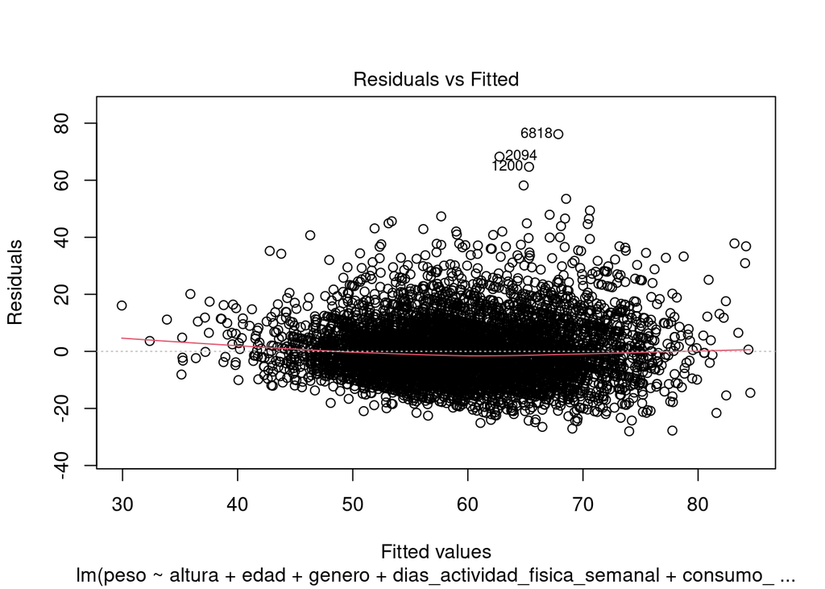

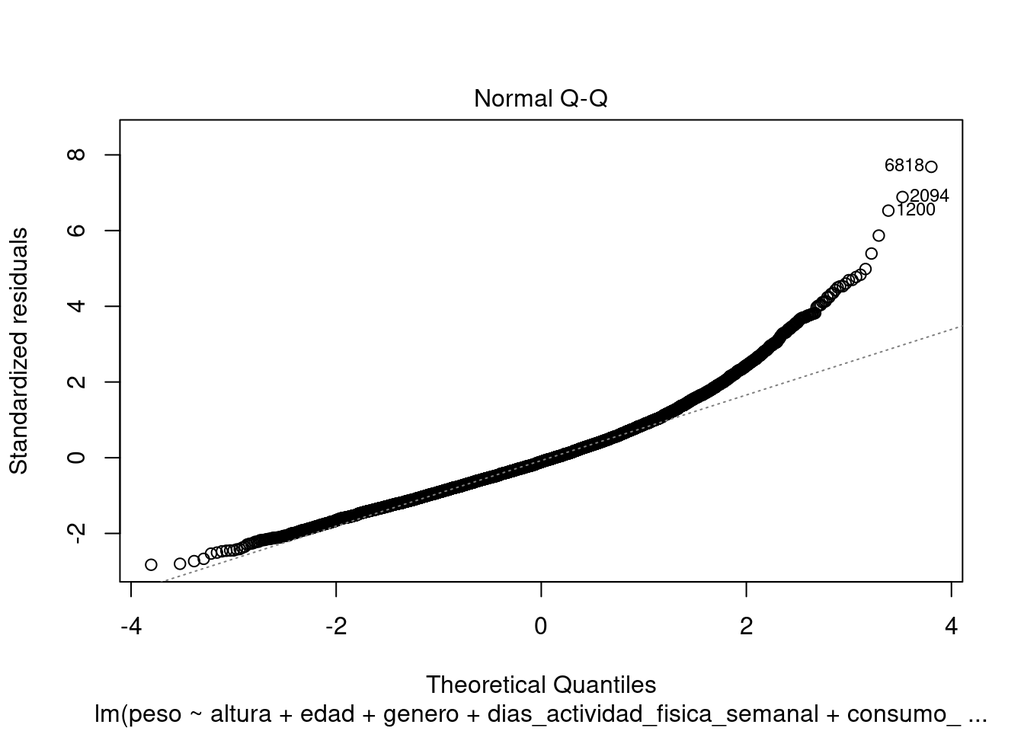

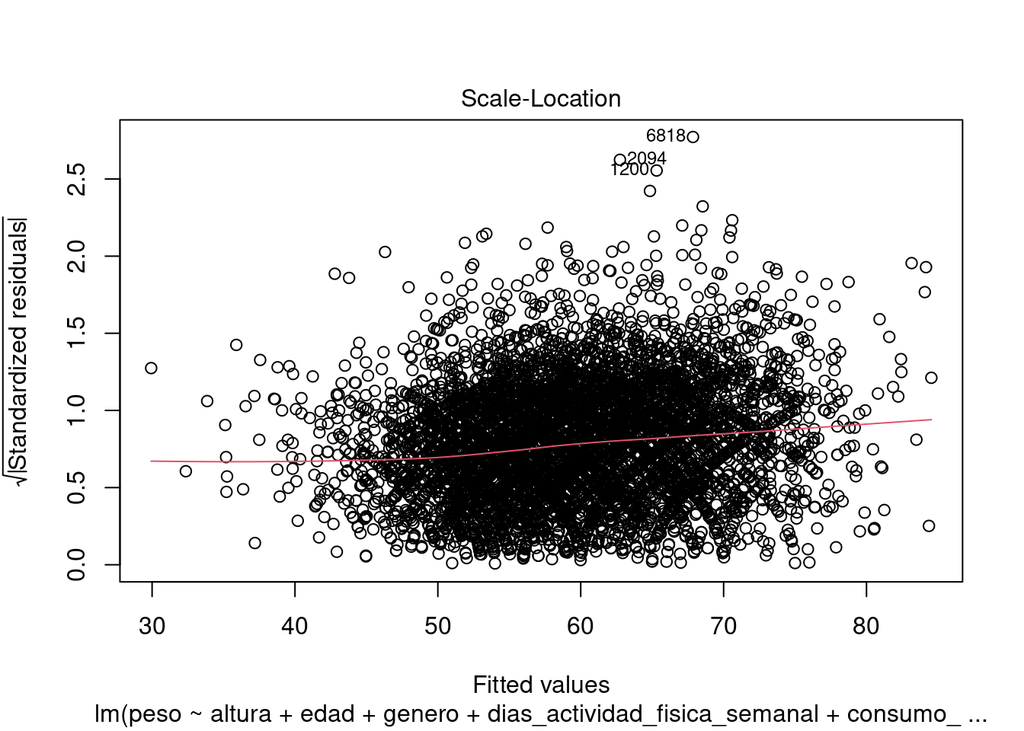

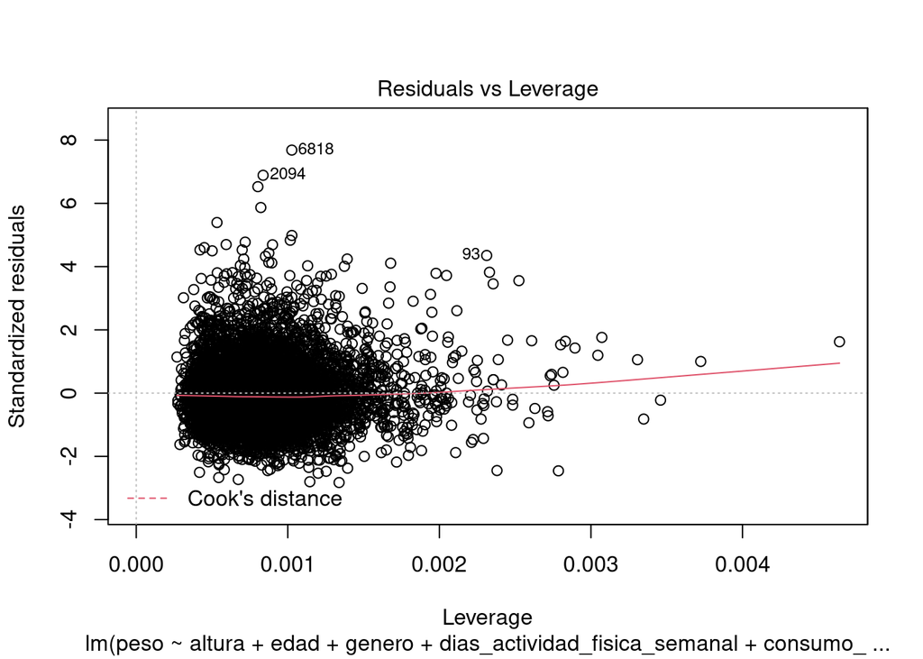

```r
# Se utiliza plot para Verificas los 4 gráficos interes de los supuesto para el modelo inicial
plot(modelo_inicial)
```

En el primer gráfico se comparan los residuos y los valores resultantes de la predicción. La curva graficada denota que hay existencia de una estructura en los datos, viendo que la varianza pareciera aumentar en los valores predichos más cercanos al eje Y. También hay una curvatura en el centro de la nube de puntos. Esto nos permite afirmar que el supuesto de homocedasticidad no esta siendo cumplido.

Ya revisando el Q-Q Plot, podemos ver que en los extremos sobre todo en el extremo superior las distribución de los errores se aleja bastante de una normal. Por lo que se define que no cumple con el supuesto de normalidad.

En conclusión, podemos afirmar que el modelo inicial no cumple con los supuesto del modelos lineal.

## 6) Modelo Robusto

Se realiza un scatter plot para hacer la visualización de la relación peso y altura del dataset de train en comparación con este nuevo dataset que llamaremos modelo6.

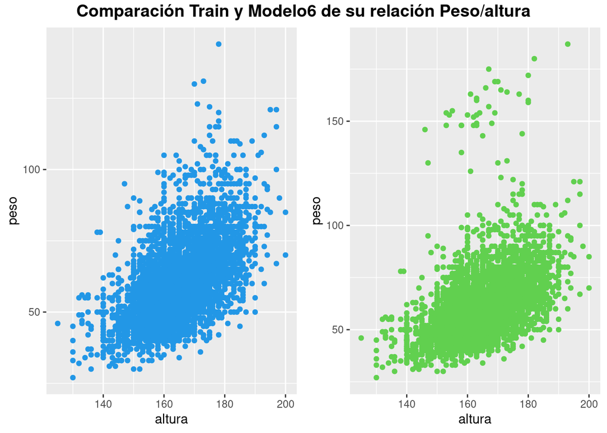

```r
# Se una ggplot para graficar los puntos del dataset de train
scatter_train <- ggplot(encuesta_train, aes(x=altura, y=peso)) + geom_point(colour = 4)

# Se una ggplot para graficar los puntos del dataset de modelo6
scatter_modelo6 <- ggplot(encuesta_modelo6, aes(x=altura, y=peso)) + geom_point(colour = 3)

#Se usa ggarrange para concatenar los gráficos
plot <- ggarrange(scatter_train, scatter_modelo6,
                    ncol = 2, nrow = 1)

# Utilizo annotate  para poner un título.
annotate_figure(plot, top = text_grob("Comparación Train y Modelo6 de su relación Peso/altura",
               color = "black", face = "bold", size = 14))
```

Se observa con claridad que en el modelo6 que existen varios puntos en el dataset con pesos mucho mayores (más de 150kg) para alturas promedio de 1.6 a 1.7 m. Es de interés poder construir un modelo que pueda implementarse para estos datos ya que no sería correcto excluirlos del análisis por considerarse outliers ya que evidentemente son personas con alguna enfermedad relacionada con el sobrepeso lo cual puede ser objetivo de un análisis distinto.

Con esta mención, se procede a utilizar la misma función para el modelo inicial pero entrenando con este nuevo dataset:

```r
# Se entrena el modelo inicial con los datos de modelo6
modelo_modelo6 <- lm(peso ~ altura + edad + genero + dias_actividad_fisica_semanal + consumo_diario_alcohol, data = encuesta_modelo6)

# Ejecuto glance de la Liberia broom para ver el R2 y R2 ajustado del modelo
broom::glance(modelo_modelo6)
```

| r.squared | adj.r.squared | sigma | statistic | p.value | df | logLik | AIC | BIC | deviance | df.residual | nobs |
| --- | --- | --- | --- | --- | --- | --- | --- | --- | --- | --- | --- |
| 0.2737421 | 0.2732273 | 12.04134 | 531.7605 | 0 | 5 | -27582.43 | 55178.85 | 55226.89 | 1022787 | 7054 | 7060 |

```r
# Utilizamos augment para predecir con nuestro modelo inicial
pred_modelo6<-  augment(modelo_modelo6, newdata = encuesta_modelo6)

#Utilizamos la función rmse y mae para calcular los errores y add_row para que que salga en una sola salida
rmse(data = pred_modelo6, truth = peso, estimate = .fitted)%>%
  add_row(mae(data = pred_modelo6, truth = peso, estimate = .fitted))
```

| .metric | .estimator | .estimate |
| --- | --- | --- |
| rmse | standard | 12.036225 |
| mae | standard | 7.966551 |

```r
#Usamos augment para generar el df con las predicciones de test
pred_modelo6 <-  augment(modelo_modelo6, newdata = encuesta_test)

#Utilizamos la función rmse y mae para calcular los errores y add_row para que que salga en una sola salida
rmse(data = pred_modelo6, truth = peso, estimate = .fitted)%>%
  add_row(mae(data = pred_modelo6, truth = peso, estimate = .fitted))
```

| .metric | .estimator | .estimate |
| --- | --- | --- |
| rmse | standard | 10.218051 |
| mae | standard | 7.649303 |

En primer lugar se observa de la salida del glance es la caída en los coeficiente de determinación en comparación con el modelo de train. Esto se debe a que por la presencia de puntos alejados de la media se logra captar un menor cantidad de variabilidad explicada.

Luego analizando los errores notamos un fuerte aumento en los errores de la predicción de los datos de entrenamiento.. De todas formas esta situación no se traslada completamente a la predicción con datos de test. Si bien hay un aumento de los errores, no es tan elevado.

Para tratar de suplir esta caída en las métricas de entrenamiento debido a que estos valores hacen crecer el error, se propone utilizar un método robusto de lmrob de la librería Robustbase:

```r
# Corremos el modelo robsuto lmrob
modelo_modelo6_robusto <- lmrob(peso ~ altura + edad + genero + dias_actividad_fisica_semanal + consumo_diario_alcohol, data = encuesta_modelo6)

#Usamos augment para generar el df con las predicciones
pred_modelo6_robusto <-  augment(modelo_modelo6_robusto, newdata = encuesta_modelo6)

#Usamos summary para ver el R2 y R ajust de nuestro modelo robusto
summary(modelo_modelo6_robusto)
```

```
##
## Call:
## lmrob(formula = peso ~ altura + edad + genero + dias_actividad_fisica_semanal +
##     consumo_diario_alcohol, data = encuesta_modelo6)
##  \--> method = "MM"
## Residuals:
##      Min       1Q   Median       3Q      Max
## -25.9082  -5.6143  -0.1514   6.0878 115.4825
##
## Coefficients:
##                                Estimate Std. Error t value Pr(>|t|)
## (Intercept)                   -63.71242    2.25261 -28.284  < 2e-16 ***
## altura                          0.62359    0.01449  43.041  < 2e-16 ***
## edad                            1.27269    0.08694  14.638  < 2e-16 ***
## generoMasculino                 1.11503    0.25240   4.418 1.01e-05 ***
## dias_actividad_fisica_semanal  -0.00211    0.04592  -0.046    0.963
## consumo_diario_alcohol          0.07219    0.05579   1.294    0.196
## ---
## Signif. codes:  0 '***' 0.001 '**' 0.01 '*' 0.05 '.' 0.1 ' ' 1
##
## Robust residual standard error: 8.579
## Multiple R-squared:  0.3869, Adjusted R-squared:  0.3865
## Convergence in 12 IRWLS iterations
##
## Robustness weights:
##  62 observations c(93,248,779,1200,1389,1657,1702,2094,2232,2637,2882,2998,3002,3656,4084,4105,4631,5043,5174,5813,6114,6251,6369,6683,6818,6956,7025,7026,7027,7028,7029,7030,7031,7032,7033,7034,7035,7036,7037,7038,7039,7040,7041,7042,7043,7044,7045,7046,7047,7048,7049,7050,7051,7052,7053,7054,70…
##   are outliers with |weight| = 0 ( < 1.4e-05);
##  572 weights are ~= 1. The remaining 6426 ones are summarized as
##      Min.   1st Qu.    Median      Mean   3rd Qu.      Max.
## 0.0000908 0.8667000 0.9513000 0.8928000 0.9858000 0.9990000
## Algorithmic parameters:
##        tuning.chi                bb        tuning.psi        refine.tol
##         1.548e+00         5.000e-01         4.685e+00         1.000e-07
##           rel.tol         scale.tol         solve.tol       eps.outlier
##         1.000e-07         1.000e-10         1.000e-07         1.416e-05
##             eps.x warn.limit.reject warn.limit.meanrw
##         3.638e-10         5.000e-01         5.000e-01
##      nResample         max.it       best.r.s       k.fast.s          k.max
##            500             50              2              1            200
##    maxit.scale      trace.lev            mts     compute.rd fast.s.large.n
##            200              0           1000              0           2000
##                   psi           subsampling                   cov
##            "bisquare"         "nonsingular"         ".vcov.avar1"
## compute.outlier.stats
##                  "SM"
## seed : int(0)
```

Con la salida de la función summary lo primero que veremos es que la significatividad de las variables es prácticamente la misma que lo que nos daba en el modelo inicial para el dataset de train.

La segunda observación a realizar es que tanto el $R^2$ como el $R^2$ ajustado vuelven a crecer considerablemente con respecto al modelo lineal múltiple no robusto:

- El $R^2$ pasa de 0.2737 a 0.3869.
- El $R^2$ ajustado pasa de 0.2732 a 0.3865.

Incluso en términos de los coeficientes de determinación logro mejorar al modelo lineal múltiple inicial con el dataset de train que tenía un $R^2$ de 0.3543754 y un $R^2$ ajustado de 0.3539. Esto indica que el dataset de train ya contiene valores que perturban al modelo lineal múltiple.

Luego revisaremos los errores RMSE y MAE con las predicciones para train y también sumaremos la predicción sobre el data set de test para evaluar sobre datos nuevos:

```r
#Utilizamos la función rmse y mae para calcular los errores y add_row para que que salga en una sola salida
rmse(data = pred_modelo6_robusto, truth = peso, estimate = .fitted)%>%
  add_row(mae(data = pred_modelo6_robusto, truth = peso, estimate = .fitted))
```

| .metric | .estimator | .estimate |
| --- | --- | --- |
| rmse | standard | 12.127697 |
| mae | standard | 7.855479 |

```r
#Usamos augment para generar el df con las predicciones de test
pred_modelo6_robusto <-  augment(modelo_modelo6_robusto, newdata = encuesta_test)

#Utilizamos la función rmse y mae para calcular los errores y add_row para que que salga en una sola salida
rmse(data = pred_modelo6_robusto, truth = peso, estimate = .fitted)%>%
  add_row(mae(data = pred_modelo6_robusto, truth = peso, estimate = .fitted))
```

| .metric | .estimator | .estimate |
| --- | --- | --- |
| rmse | standard | 10.27961 |
| mae | standard | 7.50034 |